# ECON 187 Final Project Presentation

Catherine Wu, Qiuyi Liu

2020-03-11

```r
summary(full_data)
```

```
##        id       belongs_to_collection     budget            genres
##  Min.   :   1   Length:7398           Min.   :0.00e+00   Length:7398
##  1st Qu.:1850   Class :character      1st Qu.:0.00e+00   Class :character
##  Median :3700   Mode  :character      Median :7.50e+06   Mode  :character
##  Mean   :3700                         Mean   :2.26e+07
##  3rd Qu.:5549                         3rd Qu.:2.80e+07
##  Max.   :7398                         Max.   :3.80e+08
##
##    homepage           imdb_id          original_language  original_title
##  Length:7398        Length:7398        Length:7398        Length:7398
##  Class :character   Class :character   Class :character   Class :character
##  Mode  :character   Mode  :character   Mode  :character   Mode  :character
##
##
##
##
##    overview           popularity      poster_path        production_companies
##  Length:7398        Min.   :  0.000   Length:7398        Length:7398
##  Class :character   1st Qu.:  3.933   Class :character   Class :character
##  Mode  :character   Median :  7.436   Mode  :character   Mode  :character
##                     Mean   :  8.515
##                     3rd Qu.: 10.920
##                     Max.   :547.488
##
##  production_countries release_date          runtime      spoken_languages
##  Length:7398          Length:7398        Min.   :  0.0   Length:7398
##  Class :character     Class :character   1st Qu.: 94.0   Class :character
##  Mode  :character     Mode  :character   Median :104.0   Mode  :character
##                                          Mean   :107.7
##                                          3rd Qu.:118.0
##                                          Max.   :338.0
##                                          NA's   :6
##     status            tagline             title             Keywords
##  Length:7398        Length:7398        Length:7398        Length:7398
##  Class :character   Class :character   Class :character   Class :character
##  Mode  :character   Mode  :character   Mode  :character   Mode  :character
##
##
##
##
##      cast               crew              revenue
##  Length:7398        Length:7398        Min.   :1.000e+00
##  Class :character   Class :character   1st Qu.:2.380e+06
##  Mode  :character   Mode  :character   Median :1.681e+07
##                                        Mean   :6.673e+07
##                                        3rd Qu.:6.892e+07
##                                        Max.   :1.520e+09
##                                        NA's   :4398
```

**Data Description**

# 1. Data exploration & Transformation

**a. Cleaning Data**

- According to information on Kaggle, we first manually fixed observations with incorrect information. Then we dropped observations with NA in y variable.

**b. Data Exploration**

### date and adjust for inflation

```r
full_clean_sub <- full_clean %>%
  mutate(release_date = mdy(release_date),
         quarter = quarter(release_date),
         month = month(release_date))%>%
          filter(imdb_id >= "tt0065528", between(release_date, "1980-01-01", today()))
```

- the IMDB filter ensures that we don’t accidentally “backcast” old movies. E.g., 20,000 Leagues Under the Sea was originally released in 1916, but the lubridate::mdy() function coerces it be 2016.

### Popular month

```r
full_clean_sub %>% group_by(month) %>% summarise(mean_rev=mean(revenue,na.rm=T),median_rev=median(revenue,na.rm=T)) %>% arrange(desc(median_rev)) %>% kable()
```

| month | mean_rev | median_rev |
| --- | --- | --- |
| 6 | 173376226 | 85300000 |
| 12 | 124312704 | 64303342 |
| 7 | 120567823 | 59098221 |
| 5 | 130873199 | 38610009 |
| 11 | 110312672 | 38229714 |
| 3 | 100349722 | 34742066 |
| 2 | 76203016 | 31948144 |
| 4 | 81995977 | 29086430 |
| 8 | 58474085 | 27500000 |
| 10 | 60267093 | 23875127 |
| 1 | 43397573 | 18195610 |
| 9 | 47835105 | 13727603 |

- To include seasaonlity factors into account, we rank the movie revenue based on the month they got released. According to our summary table, movies released in May, June, July, November and December have the highest mean and median revenue. The possbile explanation behind this could be that these months are holiday seasons. We then divided them into two groups: movies released in Holiday Season and others.

```r
full_clean_sub <- full_clean_sub %>% mutate(holiday=ifelse(month %in% c(5,6,7,11,12),1,0))
table(full_clean_sub$holiday) %>% kable()
```

| Var1 | Freq |
| --- | --- |
| 0 | 1210 |
| 1 | 790 |

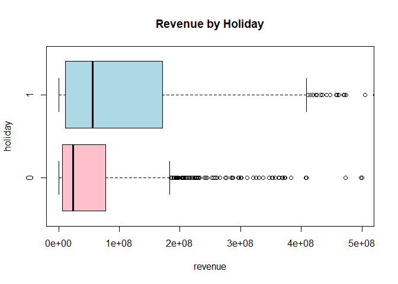

```r
boxplot(revenue~holiday, data=full_clean_sub, col=c("pink", "light blue"), main="Revenue by Holiday", horizontal = T, ylim=c(0,5.0e8))
```

### Run Time

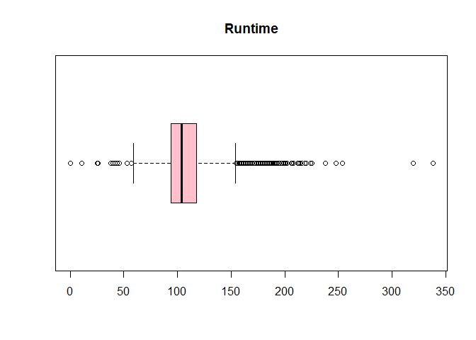

```r
boxplot(full_data$runtime, col="pink", main="Runtime", horizontal = T)
```

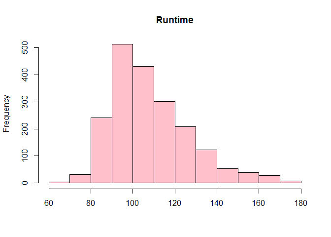

```r
full_clean_sub <- full_clean_sub %>%
  mutate(runtime = ifelse(runtime < 50, NA, ifelse(runtime > 180, NA, runtime)))

hist(full_clean_sub$runtime, main="Runtime", col="pink", xlab = " ")
```

- According to the boxplot, We removed movies with runtime longer or shorter than the normal range.

### Production Countries

```r
full_clean_sub$production_countries <- substring(full_clean_sub$production_countries, 18, 19)
country_count <- full_clean_sub %>%
  group_by(production_countries) %>%
  summarise(country_count = n(), median_rev = median(revenue, na.rm = T)) %>%
  arrange(desc(country_count))
kable(country_count)
```

| production_countries | country_count | median_rev |
| --- | --- | --- |
| US | 1244 | 41540018.5 |
| GB | 139 | 31584901.0 |
| FR | 91 | 20117339.0 |
| CA | 77 | 46201432.0 |
| DE | 71 | 57284237.0 |
| IN | 67 | 10000000.0 |
| AU | 38 | 24891880.5 |
| JP | 28 | 21369346.0 |
| CN | 26 | 55559368.0 |
| RU | 26 | 4726368.0 |
| IT | 20 | 9125716.5 |
| NA | 20 | 509020.5 |
| ES | 17 | 18469680.0 |
| MX | 11 | 21665468.0 |
| NZ | 11 | 371940071.0 |
| HK | 10 | 27644387.5 |
| CZ | 9 | 55987321.0 |
| BE | 8 | 5621348.5 |
| IE | 8 | 6493883.5 |
| KR | 8 | 9320523.5 |
| BR | 5 | 1345903.0 |
| DK | 5 | 10016934.0 |
| AE | 4 | 23739482.5 |
| AT | 4 | 1569814.5 |
| FI | 4 | 6150040.0 |
| GR | 4 | 5655874.5 |
| HU | 4 | 23541375.5 |
| NL | 4 | 636473.0 |
| SE | 3 | 2300000.0 |
| AR | 2 | 13837500.5 |
| BG | 2 | 103525315.5 |
| CH | 2 | 7560180.0 |
| CL | 2 | 3200097.0 |
| IL | 2 | 9530930.5 |
| NO | 2 | 3072170.0 |
| RO | 2 | 76697.5 |
| UA | 2 | 5106334.0 |
| ZA | 2 | 13809824.5 |
| BF | 1 | 2691899.0 |
| ID | 1 | 2627209.0 |
| IR | 1 | 900000.0 |
| IS | 1 | 203427584.0 |
| KH | 1 | 86234523.0 |
| LU | 1 | 5410749.0 |
| MR | 1 | 7406.0 |
| MT | 1 | 69411370.0 |
| NA | 1 | 4192440.0 |
| PH | 1 | 34659.0 |
| PK | 1 | 645135.0 |
| PL | 1 | 14723313.0 |
| SG | 1 | 570000.0 |
| TR | 1 | 240978.0 |
| TW | 1 | 6933459.0 |
| UY | 1 | 163794509.0 |

```r
# us vs. non-us
full_clean_sub <- full_clean_sub %>% mutate(production_country_us = ifelse(production_countries=="US","US","Non-US"))
full_clean_sub$production_country_us[which(is.na(full_clean_sub$production_country_us))] <- "US"
```

- Then we tried to explore the relationship between production countries and revenues. According to our summary table, US has a much higher number of movies than any other country, so we created another variable and divide all observations into two groups: US and Non-US.

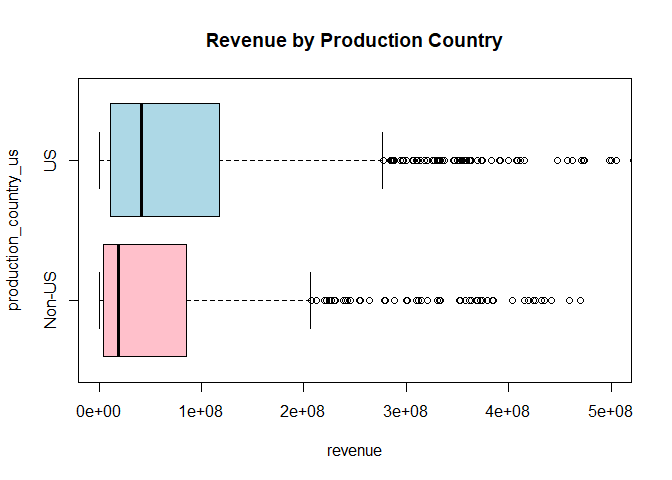

```r
boxplot(revenue~production_country_us, data=full_clean_sub, col=c("pink", "light blue"), main="Revenue by Production Country", horizontal = T, ylim=c(0,5e8))
```

### Language, English vs. Non-English

```r
full_clean_sub$Eng_NonEng <- ifelse(full_clean_sub$original_language == "en", "Eng", "Non-Eng")
table(full_clean_sub$Eng_NonEng) %>% kable()
```

| Var1 | Freq |
| --- | --- |
| Eng | 1764 |
| Non-Eng | 236 |

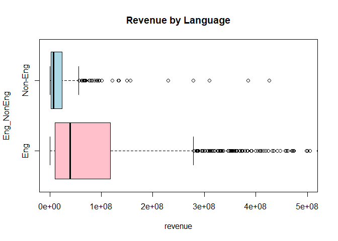

```r
boxplot(revenue~Eng_NonEng, data=full_clean_sub, col=c("pink", "light blue"), main="Revenue by Language", horizontal = T, ylim=c(0,5e8))
```

- Then we cleaned the language variable by creating a new one and dividing them into two categories: English and NonEnglish.

### Production companies

```r
full_clean_sub$production_companies <-gsub('(^\\[\\{\'name\'\\:\\s\'|\'\\,\\s\'id.*)', '',full_clean_sub$production_companies)
full_clean_sub %>%
  group_by(production_companies) %>%
  summarise(count=n()) %>%
  arrange(desc(count)) %>%
  head(20)
```

```
## # A tibble: 20 x 2
##    production_companies                   count
##    <chr>                                  <int>
##  1 Universal Pictures                       124
##  2 Paramount Pictures                       110
##  3 Twentieth Century Fox Film Corporation    79
##  4 Columbia Pictures                         77
##  5 <NA>                                      74
##  6 New Line Cinema                           63
##  7 Walt Disney Pictures                      55
##  8 Warner Bros.                              37
##  9 Miramax Films                             33
## 10 TriStar Pictures                          32
## 11 Village Roadshow Pictures                 28
## 12 Columbia Pictures Corporation             27
## 13 Fox Searchlight Pictures                  23
## 14 Summit Entertainment                      20
## 15 Touchstone Pictures                       19
## 16 DreamWorks SKG                            18
## 17 BBC Films                                 17
## 18 Lionsgate                                 17
## 19 Orion Pictures                            17
## 20 Hollywood Pictures                        15
```

```r
#separate movies from top 8 big name production companies
famous_production <- c("Universal Pictures", "Paramount Pictures",
                       "Twentieth Century Fox Film Corporation", "Columbia Pictures",
                       "New Line Cinema", "Walt Disney Pictures", "Warner Bros.")

full_clean_sub <- full_clean_sub %>%
  mutate(is_famous_production_companies = ifelse(production_companies %in% famous_production, 1, 0))
full_clean_sub <- full_clean_sub %>%
  mutate(production_companies = ifelse(production_companies %in% famous_production, production_companies, "Others"))

full_clean_sub %>% group_by(is_famous_production_companies) %>% summarise(mean(revenue, na.rm = T)) %>% kable() ##sanity check
```

| is_famous_production_companies | mean(revenue, na.rm = T) |
| --- | --- |
| 0 | 69173110 |
| 1 | 153091134 |

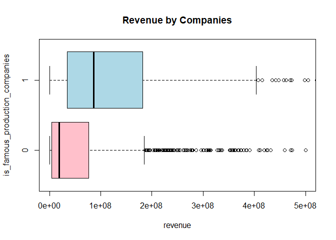

```r
boxplot(revenue~is_famous_production_companies, data=full_clean_sub, col=c("pink", "light blue"), main="Revenue by Companies", horizontal = T, ylim=c(0,5e8))
```

### Number of Cast

```r
full_clean_sub$number_of_cast <- str_count(full_clean_sub$cast, 'name')
full_clean_sub$female_cast <- str_count(full_clean_sub$cast, ('gender\'\\:\\s1'))
full_clean_sub$male_cast <- str_count(full_clean_sub$cast, ('gender\'\\:\\s2'))
full_clean_sub$cast_diff <- full_clean_sub$male_cast - full_clean_sub$female_cast
```

- To transform the Cast variable into something we can use for modeling, we created four new variables: total number of casts in a movie, number of female casts, number of male casts and the difference between the numbers.

### Genre: Main and All

```r
# categorize according to profitability
full_clean_sub %>% group_by(main_genre) %>% summarise(mean_rev=mean(revenue, na.rm=T), median_rev = median(revenue, na.rm=T)) %>% arrange(desc(mean_rev))
```

```
## # A tibble: 21 x 3
##    main_genre        mean_rev median_rev
##    <chr>                <dbl>      <dbl>
##  1 Family          236012565. 100086793
##  2 Adventure       229742848. 118847300
##  3 Western         213686700  108103450
##  4 Animation       191196418. 100491683
##  5 Science Fiction 180741637.  66821036
##  6 Action          116602326.  51000000
##  7 Fantasy         113747557   49363890.
##  8 Thriller         73672698.  40400657
##  9 Comedy           66705338.  33451482
## 10 Mystery          64464054.  30658387
## # ... with 11 more rows
```

```r
profit_genre <- c("Adventure","Science Fiction","Family","Animation","Western","Action","Fantasy")
full_clean_sub <- full_clean_sub %>%
  mutate(main_genre_profit = ifelse(main_genre %in% profit_genre, 1, 0))
full_clean_sub %>% group_by(main_genre_profit) %>% summarise(mean=mean(revenue,na.rm=T), count=n())
```

```
## # A tibble: 2 x 3
##   main_genre_profit       mean count
##               <dbl>      <dbl> <int>
## 1                 0  58463878.  1293
## 2                 1 153448017.   707
```

```r
# Categorize according to their quantities(keep genres with more than 100 movies)
top_genre <- c("Drama","Comedy","Action","Adventure","Horror","Crime","Thriller")
full_clean_sub <- full_clean_sub %>%
  mutate(main_genre_top = ifelse(main_genre %in% top_genre, 1, 0))
```

- We then modified the genre variable. Given the large number of categories, we first divided them into two groups, profitable ones vs. less profitable ones, then divided them into popular and non-popular one according to their quantities.

### Words in tag, title, overview, keywords

- We also created variables regarding the number of words in tag, title and overview.

### Drop not useful variables

```r
data <- subset(full_clean_sub, select=c(revenue,budget,is_famous_production_companies,production_country_us,Eng_NonEng,number_of_cast, female_cast, male_cast, words_in_tag,words_in_title,words_overview,number_keywords, main_genre_top,main_genre_profit, holiday, quarter, runtime, popularity ))
```

- We dropped irrelevant variables, for example, “imdb_id”, “original language”, “poster_path”, and “status”(since 98% of them are already released).

### Percentage of NA in each variables

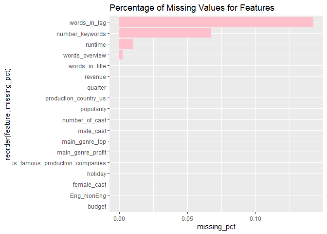

```r
datanew <- data
tidyr::gather(summarize_each(datanew, funs(sum(is.na(.))/n())), key = "feature", value = "missing_pct") %>% ggplot(aes(reorder(feature, missing_pct), missing_pct)) +
  geom_bar(stat = "identity", fill="pink") +
  coord_flip() +
  ggtitle("Percentage of Missing Values for Features")
```

### Change Characters to Factors

```r
datanew$quarter <- as.factor(datanew$quarter)
datanew$main_genre_profit <- as.factor(datanew$main_genre_profit)
datanew$main_genre_top <- as.factor(datanew$main_genre_top)
datanew$Eng_NonEng <- as.factor(datanew$Eng_NonEng)
datanew$production_country_us <- as.factor(datanew$production_country_us)
datanew$is_famous_production_companies <- as.factor(datanew$is_famous_production_companies)
datanew$holiday <- as.factor(datanew$holiday)
```

- As our last step of data cleaning, we checked for the missing observations and use mean values to impute them.

# 2. Initial Model Selection

- We first split the data into training and testing by half and half. Then we run the magic Train_control to get an idea on which kind of model we should use.

### Train_control

```r
# Set training control
train_control <- trainControl(method = "cv",
                              number = 10,
                              search = "random")
# linear model
lm_model <- train(revenue ~ .,
                           data = datanew,
                           method = "lm",
                           trControl = train_control,
                           preProc = c("center", "scale"))
print(lm_model)
```

```
## Linear Regression
##
## 2000 samples
##   17 predictor
##
## Pre-processing: centered (19), scaled (19)
## Resampling: Cross-Validated (10 fold)
## Summary of sample sizes: 1800, 1800, 1800, 1800, 1800, 1800, ...
## Resampling results:
##
##   RMSE      Rsquared   MAE
##   99425828  0.6076713  58614842
##
## Tuning parameter 'intercept' was held constant at a value of TRUE
```

```r
# LASSO
lasso_model <- train(revenue ~ .,
                           data = datanew,
                           method = "lasso",
                           trControl = train_control,
                          preProc = c("center", "scale"))

print(lasso_model)
```

```
## The lasso
##
## 2000 samples
##   17 predictor
##
## Pre-processing: centered (19), scaled (19)
## Resampling: Cross-Validated (10 fold)
## Summary of sample sizes: 1800, 1800, 1800, 1800, 1800, 1800, ...
## Resampling results across tuning parameters:
##
##   fraction   RMSE       Rsquared   MAE
##   0.6447080  100638744  0.5969849  56589121
##   0.6820018  100061421  0.6003055  56489190
##   0.6835539  100043569  0.6004084  56493789
##
## RMSE was used to select the optimal model using the smallest value.
## The final value used for the model was fraction = 0.6835539.
```

```r
# Random Forest
rf_model <- train(revenue ~ .,
                           data = datanew,
                           method = "rf",
                           trControl = train_control,
                          preProc = c("center", "scale"))
print(rf_model)
```

```
## Random Forest
##
## 2000 samples
##   17 predictor
##
## Pre-processing: centered (19), scaled (19)
## Resampling: Cross-Validated (10 fold)
## Summary of sample sizes: 1800, 1800, 1800, 1800, 1800, 1800, ...
## Resampling results across tuning parameters:
##
##   mtry  RMSE      Rsquared   MAE
##   11    93858978  0.6542061  53128974
##   14    94268881  0.6521938  53216522
##   16    94988474  0.6470228  53711069
##
## RMSE was used to select the optimal model using the smallest value.
## The final value used for the model was mtry = 11.
```

- The results suggest that random forest outperforms the other two since it has the lowest RMSE and the highest Rsquared. We will try to improve our linear models to see if the Rsquared could be higher.

**2.1 Linear Regression Models**

### Model 1: MLR with all variables

```r
lm1 <- lm(revenue ~., data=train_df)
summary(lm1)
```

```
##
## Call:
## lm(formula = revenue ~ ., data = train_df)
##
## Residuals:
##        Min         1Q     Median         3Q        Max
## -368012514  -39706208   -4065926   23277519  620302249
##
## Coefficients:
##                                   Estimate Std. Error t value Pr(>|t|)
## (Intercept)                     -4.064e+07  2.228e+07  -1.824 0.068467 .
## budget                           2.373e+00  9.219e-02  25.739  < 2e-16 ***
## is_famous_production_companies1  1.991e+07  6.533e+06   3.048 0.002368 **
## production_country_usUS          5.328e+06  6.606e+06   0.806 0.420152
## Eng_NonEngNon-Eng                1.664e+07  1.045e+07   1.593 0.111483
## number_of_cast                   2.625e+05  3.075e+05   0.854 0.393512
## female_cast                      7.076e+05  7.328e+05   0.966 0.334461
## male_cast                       -3.880e+05  5.751e+05  -0.675 0.500026
## words_in_tag                    -6.220e+05  6.919e+05  -0.899 0.368946
## words_in_title                   4.093e+06  1.832e+06   2.234 0.025722 *
## words_overview                   8.769e+04  1.063e+05   0.825 0.409705
## number_keywords                  1.773e+06  4.850e+05   3.655 0.000271 ***
## main_genre_top1                 -1.503e+07  7.825e+06  -1.921 0.055009 .
## main_genre_profit1               5.395e+06  6.480e+06   0.833 0.405289
## holiday1                         1.054e+07  6.895e+06   1.528 0.126736
## quarter2                        -7.968e+05  9.314e+06  -0.086 0.931839
## quarter3                        -2.681e+06  8.088e+06  -0.331 0.740388
## quarter4                        -8.075e+06  9.020e+06  -0.895 0.370862
## runtime                         -5.070e+04  1.706e+05  -0.297 0.766344
## popularity                       2.299e+06  1.876e+05  12.250  < 2e-16 ***
## ---
## Signif. codes:  0 '***' 0.001 '**' 0.01 '*' 0.05 '.' 0.1 ' ' 1
##
## Residual standard error: 87310000 on 980 degrees of freedom
## Multiple R-squared:  0.6454, Adjusted R-squared:  0.6385
## F-statistic: 93.88 on 19 and 980 DF,  p-value: < 2.2e-16
```

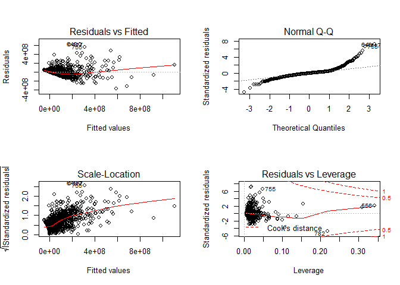

```r
par(mfrow=c(2,2))
plot(lm1)
```

### Model 2: MLR which only keeps significant factors

```r
lm2 <- lm(revenue ~ budget+is_famous_production_companies+number_keywords+main_genre_top+popularity, data=train_df)
summary(lm2)
```

```
##
## Call:
## lm(formula = revenue ~ budget + is_famous_production_companies +
##     number_keywords + main_genre_top + popularity, data = train_df)
##
## Residuals:
##        Min         1Q     Median         3Q        Max
## -370616228  -39007898   -4150827   24735459  645177653
##
## Coefficients:
##                                   Estimate Std. Error t value Pr(>|t|)
## (Intercept)                     -2.111e+07  8.509e+06  -2.481 0.013276 *
## budget                           2.419e+00  7.847e-02  30.828  < 2e-16 ***
## is_famous_production_companies1  2.074e+07  6.366e+06   3.258 0.001160 **
## number_keywords                  1.793e+06  4.755e+05   3.771 0.000172 ***
## main_genre_top1                 -1.888e+07  7.675e+06  -2.460 0.014050 *
## popularity                       2.354e+06  1.785e+05  13.185  < 2e-16 ***
## ---
## Signif. codes:  0 '***' 0.001 '**' 0.01 '*' 0.05 '.' 0.1 ' ' 1
##
## Residual standard error: 87540000 on 994 degrees of freedom
## Multiple R-squared:  0.6384, Adjusted R-squared:  0.6366
## F-statistic:   351 on 5 and 994 DF,  p-value: < 2.2e-16
```

### Model 3: MLR only keeps significant factors, remove bad leverage

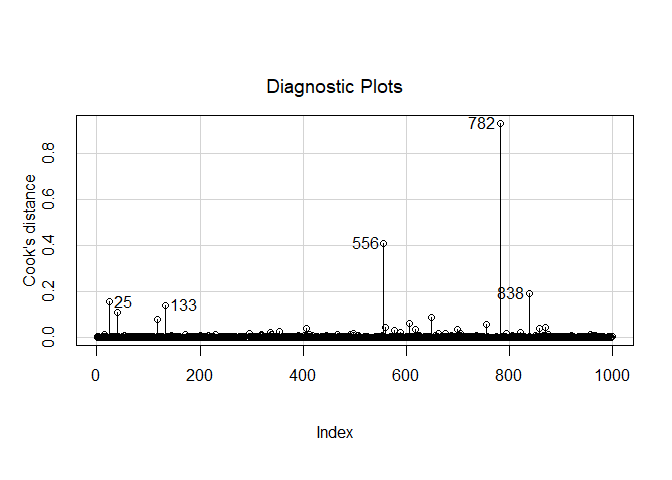

```r
influenceIndexPlot(lm2, var="cook", id=list(n=5))
```

```r
train_df_new <- train_df[c(-556,-782),]
lm3 <- lm(revenue ~ budget+is_famous_production_companies+number_keywords+main_genre_top+popularity, data=train_df_new)
summary(lm3)
```

```
##
## Call:
## lm(formula = revenue ~ budget + is_famous_production_companies +
##     number_keywords + main_genre_top + popularity, data = train_df_new)
##
## Residuals:
##        Min         1Q     Median         3Q        Max
## -343157620  -39040067   -4659089   24350372  647014187
##
## Coefficients:
##                                   Estimate Std. Error t value Pr(>|t|)
## (Intercept)                     -2.264e+07  8.439e+06  -2.682 0.007433 **
## budget                           2.381e+00  7.872e-02  30.252  < 2e-16 ***
## is_famous_production_companies1  1.951e+07  6.304e+06   3.095 0.002024 **
## number_keywords                  1.731e+06  4.711e+05   3.675 0.000251 ***
## main_genre_top1                 -1.752e+07  7.610e+06  -2.302 0.021556 *
## popularity                       2.629e+06  2.455e+05  10.709  < 2e-16 ***
## ---
## Signif. codes:  0 '***' 0.001 '**' 0.01 '*' 0.05 '.' 0.1 ' ' 1
##
## Residual standard error: 86600000 on 992 degrees of freedom
## Multiple R-squared:  0.6218, Adjusted R-squared:  0.6199
## F-statistic: 326.2 on 5 and 992 DF,  p-value: < 2.2e-16
```

### Model 4: MLR with power transformation

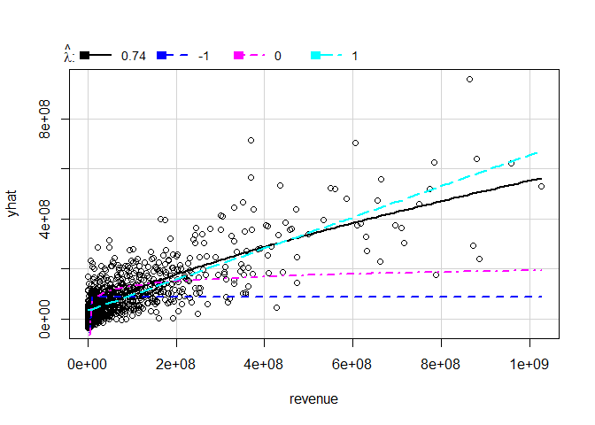

```
##       lambda          RSS
## 1  0.7368966 4.404577e+18
## 2 -1.0000000 1.206018e+19
## 3  0.0000000 7.991892e+18
## 4  1.0000000 4.625887e+18
```

```r
inverseResponsePlot(lm3)
```

```r
lm4 <- lm(revenue^0.7 ~ budget+is_famous_production_companies+number_keywords+main_genre_top+popularity, data=train_df_new)
summary(lm4)
```

```
##
## Call:
## lm(formula = revenue^0.7 ~ budget + is_famous_production_companies +
##     number_keywords + main_genre_top + popularity, data = train_df_new)
##
## Residuals:
##     Min      1Q  Median      3Q     Max
## -692030 -106630  -26983   75902 1194255
##
## Coefficients:
##                                   Estimate Std. Error t value Pr(>|t|)
## (Intercept)                      8.485e+03  1.957e+04   0.434   0.6647
## budget                           5.727e-03  1.826e-04  31.366  < 2e-16 ***
## is_famous_production_companies1  8.133e+04  1.462e+04   5.562 3.43e-08 ***
## number_keywords                  5.433e+03  1.093e+03   4.972 7.82e-07 ***
## main_genre_top1                 -3.085e+04  1.765e+04  -1.748   0.0808 .
## popularity                       5.588e+03  5.695e+02   9.813  < 2e-16 ***
## ---
## Signif. codes:  0 '***' 0.001 '**' 0.01 '*' 0.05 '.' 0.1 ' ' 1
##
## Residual standard error: 200900 on 992 degrees of freedom
## Multiple R-squared:  0.6426, Adjusted R-squared:  0.6408
## F-statistic: 356.7 on 5 and 992 DF,  p-value: < 2.2e-16
```

```r
vif(lm4)
```

```
##                         budget is_famous_production_companies
##                       1.208491                       1.094775
##                number_keywords                 main_genre_top
##                       1.018475                       1.005800
##                     popularity
##                       1.138132
```

- Our final linear model consists of five variables: budget, whether it is a famous production company, number of keywords, whether it is among the main genre and popularity. The Adjusted R-squared is 64.08%. No Multicollinearity problems presented.

###Testing set rsq

```r
# fit testing data
lm4_pred <- predict(lm4,newdata = test_df)
lm4_pred_trans <- lm4_pred^(1/0.7)
lm4_pred_trans[is.na(lm4_pred_trans)] <- mean(lm4_pred_trans, na.rm=T)
pred <- lm4_pred_trans
### find R^2
actual <- (test_df$revenue)
rss <- sum((pred - actual) ^ 2)
tss <- sum((actual - mean(actual)) ^ 2)
rsq <- 1 - rss/tss
```

### Mallow CP

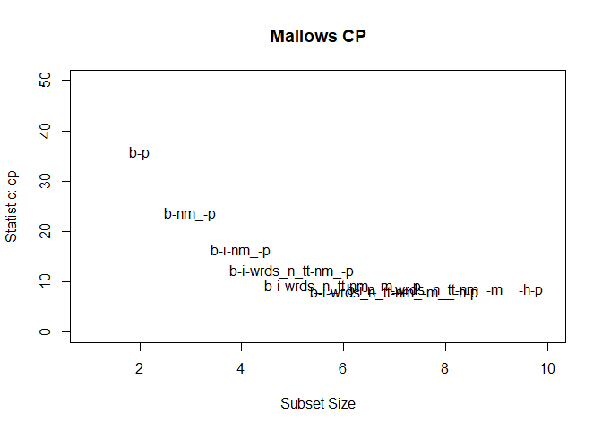

```
##                                 Abbreviation
## budget                                     b
## is_famous_production_companies1            i
## number_of_cast                           n__
## male_cast                                ml_
## words_in_tag                       wrds_n_tg
## words_in_title                     wrds_n_tt
## number_keywords                          nm_
## main_genre_top1                          m__
## holiday1                                   h
## popularity                                 p
```

```r
ss=regsubsets(revenue ~ budget+is_famous_production_companies+number_of_cast+male_cast+words_in_tag+words_in_title+number_keywords+main_genre_top+holiday+popularity, data=train_df_new)
subsets(ss,statistic="cp",legend=F,main="Mallows CP",col="steelblue4", ylim=c(0,50))
```

- According to Mallow’s CP, we further shrink our model to four predictors: budget, is_famous_production_companies, number of keywords, popularity.

```r
lm6 <- lm(revenue^0.7 ~ budget+is_famous_production_companies+number_keywords+popularity, data=train_df_new)
summary(lm6)
```

```
##
## Call:
## lm(formula = revenue^0.7 ~ budget + is_famous_production_companies +
##     number_keywords + popularity, data = train_df_new)
##
## Residuals:
##     Min      1Q  Median      3Q     Max
## -697589 -107742  -26483   78939 1218924
##
## Coefficients:
##                                   Estimate Std. Error t value Pr(>|t|)
## (Intercept)                     -1.771e+04  1.261e+04  -1.404    0.161
## budget                           5.750e-03  1.823e-04  31.545  < 2e-16 ***
## is_famous_production_companies1  8.086e+04  1.464e+04   5.525 4.21e-08 ***
## number_keywords                  5.388e+03  1.094e+03   4.927 9.77e-07 ***
## popularity                       5.572e+03  5.700e+02   9.775  < 2e-16 ***
## ---
## Signif. codes:  0 '***' 0.001 '**' 0.01 '*' 0.05 '.' 0.1 ' ' 1
##
## Residual standard error: 201100 on 993 degrees of freedom
## Multiple R-squared:  0.6415, Adjusted R-squared:   0.64
## F-statistic: 444.2 on 4 and 993 DF,  p-value: < 2.2e-16
```

```r
# Power Transformation
summary(powerTransform(cbind(revenue,budget,popularity,number_keywords)~1, data=train_df_new))
```

```
## bcPower Transformations to Multinormality
##                 Est Power Rounded Pwr Wald Lwr Bnd Wald Upr Bnd
## revenue            0.2153        0.22       0.1939       0.2368
## budget             0.2745        0.27       0.2431       0.3058
## popularity         0.2837        0.28       0.2520       0.3154
## number_keywords    0.2895        0.33       0.2212       0.3578
##
## Likelihood ratio test that transformation parameters are equal to 0
##  (all log transformations)
##                                  LRT df       pval
## LR test, lambda = (0 0 0 0) 1092.076  4 < 2.22e-16
##
## Likelihood ratio test that no transformations are needed
##                                 LRT df       pval
## LR test, lambda = (1 1 1 1) 5518.81  4 < 2.22e-16
```

```r
lm7 <- lm(revenue^0.2 ~ I(budget^0.27)+is_famous_production_companies+I(number_keywords^0.33)+I(popularity^0.28), data=train_df_new)
summary(lm7)
```

```
##
## Call:
## lm(formula = revenue^0.2 ~ I(budget^0.27) + is_famous_production_companies +
##     I(number_keywords^0.33) + I(popularity^0.28), data = train_df_new)
##
## Residuals:
##      Min       1Q   Median       3Q      Max
## -25.9441  -4.4661   0.6195   5.2495  30.4381
##
## Coefficients:
##                                  Estimate Std. Error t value Pr(>|t|)
## (Intercept)                     -6.923889   1.362930  -5.080 4.50e-07 ***
## I(budget^0.27)                   0.209876   0.008948  23.454  < 2e-16 ***
## is_famous_production_companies1  3.636252   0.567660   6.406 2.31e-10 ***
## I(number_keywords^0.33)          2.442325   0.544341   4.487 8.08e-06 ***
## I(popularity^0.28)               7.331621   0.700806  10.462  < 2e-16 ***
## ---
## Signif. codes:  0 '***' 0.001 '**' 0.01 '*' 0.05 '.' 0.1 ' ' 1
##
## Residual standard error: 7.628 on 993 degrees of freedom
## Multiple R-squared:  0.6105, Adjusted R-squared:  0.6089
## F-statistic:   389 on 4 and 993 DF,  p-value: < 2.2e-16
```

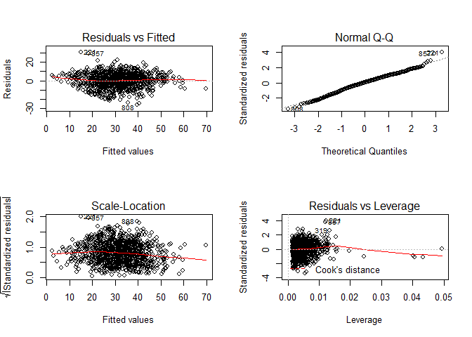

```r
par(mfrow=c(2,2))
plot(lm7)
```

```r
ncvTest(lm7)
```

```
## Non-constant Variance Score Test
## Variance formula: ~ fitted.values
## Chisquare = 5.718894, Df = 1, p = 0.016783
```

```r
vif(lm7)
```

```
##                 I(budget^0.27) is_famous_production_companies
##                       1.418968                       1.143938
##        I(number_keywords^0.33)             I(popularity^0.28)
##                       1.068746                       1.374747
```

### Regularization

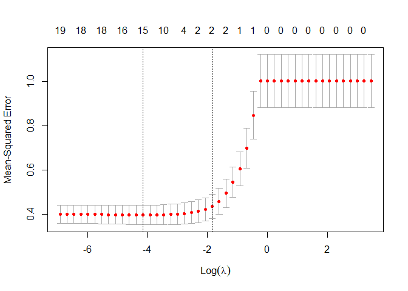

```r
# LASSO
X <- model.matrix(revenue~.,train_df_new)[,-1]
y <-  train_df_new$revenue %>% scale(center=TRUE, scale=TRUE) %>% as.matrix()
xtest <- model.matrix(revenue~.,test_df)[,-1]
grid=10^seq(1.5,-3,by=-0.1)
cv.lasso=cv.glmnet(X,y, alpha=1,lambda = grid, standardize = TRUE, nfolds = 10)

best_lam_lasso = cv.lasso$lambda.min
plot(cv.lasso)
```

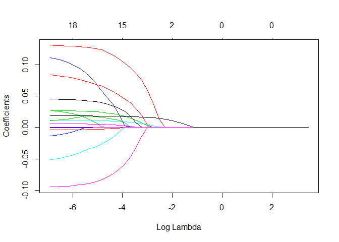

```r
lasso_fit= glmnet(X,y, alpha=1, lambda = grid, standardize = TRUE)
plot(lasso_fit,xvar="lambda")
```

```r
lasso.best <- glmnet(X,y,alpha=1,lambda = best_lam_lasso, standardize = TRUE)
coef(lasso.best)
```

```
## 20 x 1 sparse Matrix of class "dgCMatrix"
##                                            s0
## (Intercept)                     -8.881439e-01
## budget                           1.634342e-08
## is_famous_production_companies1  1.099740e-01
## production_country_usUS          .
## Eng_NonEngNon-Eng                2.133110e-02
## number_of_cast                   3.454480e-04
## female_cast                      3.450233e-03
## male_cast                        .
## words_in_tag                    -8.317537e-04
## words_in_title                   2.014590e-02
## words_overview                   1.738405e-04
## number_keywords                  9.577929e-03
## main_genre_top1                 -6.694349e-02
## main_genre_profit1               3.073831e-02
## holiday1                         5.183280e-02
## quarter2                         1.123206e-02
## quarter3                         .
## quarter4                        -7.319712e-03
## runtime                          .
## popularity                       1.781287e-02
```

```r
pred <- predict(lasso.best, s = best_lam_lasso, newx = xtest)

### find R^2
actual <- (test_df$revenue) %>% scale()
rss <- sum((pred - actual) ^ 2)
tss <- sum((actual - mean(actual)) ^ 2)
rsq <- 1 - rss/tss
rsq
```

```
## [1] 0.5912404
```

*2.2 Other Models*

### PCR

```r
pcr.fit=pcr(revenue ~ budget+is_famous_production_companies+number_of_cast+number_keywords+holiday, data=train_df_new,scale=TRUE,validation ="CV")
summary(pcr.fit)
```

```
## Data:    X dimension: 998 5
##  Y dimension: 998 1
## Fit method: svdpc
## Number of components considered: 5
##
## VALIDATION: RMSEP
## Cross-validated using 10 random segments.
##        (Intercept)    1 comps    2 comps    3 comps    4 comps   5 comps
## CV       140535461  106450105  106107364  105728172  105418467  91580730
## adjCV    140535461  106405256  106074965  105719150  105402689  91546225
##
## TRAINING: % variance explained
##          1 comps  2 comps  3 comps  4 comps  5 comps
## X          32.78    52.94    71.25    87.81   100.00
## revenue    42.89    43.28    43.70    44.22    58.06
```

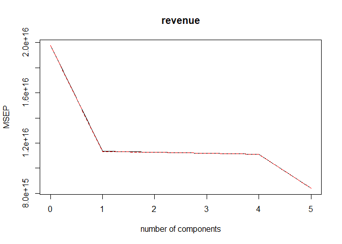

```r
validationplot(pcr.fit,val.type="MSEP")
```

- The results indicate that we need to use all the components, therefore we decided to pass it and focus on random forest.

### Decision Tree

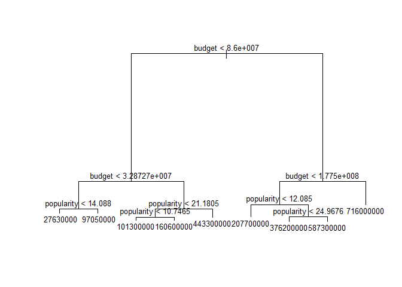

```r
tree.model <- tree(revenue ~ budget+is_famous_production_companies+number_keywords+popularity, data=train_df_new)
plot(tree.model)
text(tree.model,cex=0.8)
```

- According to decision tree, Budget and popularity are the most important variables.

*2.3 Final Model: Random Forest*

```r
set.seed(12348)
rf_default <- randomForest(revenue^0.5~., data = train_df_new, ntree = 500, important = T)
print(rf_default)
```

```
##
## Call:
##  randomForest(formula = revenue^0.5 ~ ., data = train_df_new,      ntree = 500, important = T)
##                Type of random forest: regression
##                      Number of trees: 500
## No. of variables tried at each split: 5
##
##           Mean of squared residuals: 12883494
##                     % Var explained: 64.11
```

```r
## variable importance (i.e.mean decrease in node impurity)
importance <- importance(rf_default)
feature_imp <- data.frame(importance) %>%
  arrange(-IncNodePurity) %>%
  mutate(mean_decrease_accuracy = round(IncNodePurity/sum(IncNodePurity) * 100, 2))

varImportance <- data.frame(Variables = row.names(importance), Importance = feature_imp$mean_decrease_accuracy) %>% arrange(-Importance) %>% top_n(10)
```

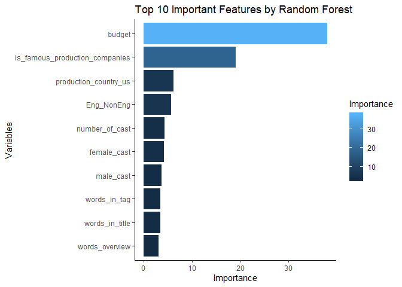

```r
rankImportance <- varImportance %>%
  mutate(Rank=paste0('#',dense_rank(desc(varImportance$Importance))))
rankImportance[10,"Rank"] <- ""

rf_plot <- ggplot(rankImportance, aes(x=reorder(Variables, Importance), y=Importance, fill=Importance))+
 geom_bar(stat='identity') +
 labs(x = 'Variables') +
 coord_flip() +
 theme_classic() +
  ggtitle("Top 10 Important Features by Random Forest")
rf_plot
```

```r
rf_pred <- predict(rf_default, test_df) #make prediction
```

# 3. Description of our model & Future improvements